# Education as risk factor of mild cognitive impairment: the link to the gut microbiome

MAKLEE & VTEA

10 September 2023

The following chunk is run once to initialize the pipeline, which

- merges clinical and 16S rRNA sequencing data (phyloseq object)
- computes metrics of alpha diversity and beta dispersion
- tests differential abundance
- tests mediation with CMAverse

See _targets.R for more information.

```r
# tar_make()
```

All analyses were run in R (R version 4.3.1 (2023-06-16)). Please note the session info for package version information.

[session information not shown]

# Manuscript

## Table 1. Baseline Characteristics of Participants.

|  | NC | MCI | p | p test |
| --- | --- | --- | --- | --- |
| n | 200 | 58 |  |  |
| Gender (Female/Male) | 87/113 | 15/43 | 0.022 | fisher |
| Years of Education (0-10/11-16/16+) | 24/110/66 | 16/24/18 | 0.018 | fisher |
| First Language (Other/French/Luxembourgish/German) | 18/182 | 6/52 | 0.798 | fisher |
| Living With Partner (No/Yes) | 61/139 | 17/41 | 1.000 | fisher |
| BDI I mild (Yes/No) | 23/177 | 9/49 | 0.497 | fisher |
| APOE4 (At Least 1/None) | 54/146 | 19/39 | 0.410 | fisher |
| ATB in last 6 months (YES/NO) | 21/179 | 9/49 | 0.351 | fisher |
| Age | 63.76 ± 7.84 | 67.6 ± 9 | 0.004 | t |
| BMI | 27.04 ± 4.37 | 29.74 ± 5.91 | 0.002 | t |
| Chao1 | 311.56 ± 64.96 | 295.05 ± 86.37 | 0.181 | t |
| Shannon | 3.99 ± 0.38 | 3.93 ± 0.46 | 0.415 | t |
| InvSimpson | 27.75 ± 11.46 | 26.79 ± 11.66 | 0.580 | t |

Note. T = Student’s t-Test, Fisher = Fisher’s Exact Test. Numbers refer to means ± standard deviations for continuous, n for categorical characteristics. BMI = body mass index, BDI-I = Beck Depression Inventory I, APOE = apolipoprotein ε4 status.

```
## Mean age (SD) age of participants = 64.6 ( 8.3 ) years
```

## Table 2. Taxonomic Analysis Across Groups of Education (DESeq2).

### Basic Adjustments

| Level | Taxon | low.high | low.int |
| --- | --- | --- | --- |
| Class | Actinobacteria | 0.035 |  |
| Class | Bacilli | 0.008 |  |
| Family | Streptococcaceae |  | 0.018 |
| Genus | Streptococcus |  | 0.048 |
| Order | Lactobacillales |  | 0.009 |

<sup>a</sup> Shown results are restricted to p < .05.

Adjusted for age, sex/gender, BMI, and use of antibiotic medication in the last 6 months.

### Basic + Further Adjustments

| Level | Taxon | low.high | low.int |
| --- | --- | --- | --- |
| Class | Bacilli | 0.009 |  |
| Family | Streptococcaceae |  | 0.029 |
| Order | Lactobacillales |  | 0.016 |

<sup>a</sup> Shown results are restricted to p < .05.

Adjusted for age, sex/gender, BMI, use of antibiotic medication in the last 6 months, BDI-I, first language, and partnership status.

### Basic + Further Adjustments + APOE

| Level | Taxon | low.high | low.int |
| --- | --- | --- | --- |
| Class | Bacilli | 0.01 |  |
| Family | Streptococcaceae |  | 0.044 |
| Order | Lactobacillales |  | 0.024 |

<sup>a</sup> Shown results are restricted to p < .05.

Adjusted for age, sex/gender, BMI, use of antibiotic medication in the last 6 months, BDI-I, first language, partnership status and APOE.

## Table 2. Taxonomic Analysis Across Groups of Education (ANCOM-BC).

### Basic Adjustments

| Level | Taxon | low.high |
| --- | --- | --- |
| Genus | Lachnospiraceae_UCG_001 | 0.009 |
| ASV | OTU_000053 | 0.048 |
| ASV | OTU_000508 | 0.048 |

<sup>a</sup> Shown results are restricted to p < .05.

Adjusted for age, sex/gender, BMI, and use of antibiotic medication in the last 6 months.

### Basic + Further Adjustments

| Level | Taxon | low.high |
| --- | --- | --- |
| Genus | Lachnospiraceae_UCG_001 | 0.019 |

<sup>a</sup> Shown results are restricted to p < .05.

Adjusted for age, sex/gender, BMI, use of antibiotic medication in the last 6 months, BDI-I, first language, and partnership status.

### Basic + Further Adjustments + APOE

| Level | Taxon | low.high |
| --- | --- | --- |
| Genus | Lachnospiraceae_UCG_001 | 0.021 |

<sup>a</sup> Shown results are restricted to p < .05.

Adjusted for age, sex/gender, BMI, use of antibiotic medication in the last 6 months, BDI-I, first language, partnership status and APOE.

## Table 3. Mediation Analysis with Chao1 as Mediator.

Note. Results of mediation analysis with interaction terms of education and Chao1 in the outcome model. Standard errors were estimated with 2000 bootstraps. * P Value < .05, ** P Value < .01, *** P Value < .001. Rcde: controlled direct effect odds ratio (referring to CDE); Rpnde: pure natural direct effect odds ratio (referring to NDE); Rtnde: total natural direct effect odds ratio; Rpnie: pure natural indirect effect odds ratio; Rtnie: total natural indirect effect odds ratio (referring to NIE); Rte: total effect odds ratio; Ercde: excess relative risk due to controlled direct effect; Erintref: excess relative risk due to reference interaction; Erintmed: excess relative risk due to mediated interaction; Erpnie: excess relative risk due to pure natural indirect effect; Ercde(P): proportion Ercde; Erintref(P): proportion Erintref; Erintmed(P): proportion Erintmed; Erpnie(P): proportion Erpnie; pm: overall proportion mediated; int: overall proportion attributable to interaction; pe: overall proportion eliminated). Cells with – indicate n/a.

### 0-10 vs. 11-16

11-16 vs. 0-10 YEDU - Chao1 - no interaction

| Effect | Estimate [95% CI] | P Value | Sig |
| --- | --- | --- | --- |
| Rcde | 0.34 [ 0.16 to 0.74] | 0.010 | ’*’ |
| Rpnde | 0.34 [ 0.16 to 0.74] | 0.010 | ’*’ |
| Rtnde | 0.34 [ 0.16 to 0.74] | 0.010 | ’*’ |
| Rpnie | 0.92 [ 0.77 to 1.07] | 0.284 |  |
| Rtnie | 0.92 [ 0.76 to 1.07] | 0.284 |  |
| Rte | 0.32 [ 0.15 to 0.68] | 0.006 | ’**’ |
| pm | 0.04 [-0.04 to 0.25] | 0.288 |  |

### 0-10 vs. 16+

16+ vs. 0-10 YEDU - Chao1 - no interaction

| Effect | Estimate [95% CI] | P Value | Sig |
| --- | --- | --- | --- |
| Rcde | 0.33 [ 0.15 to 0.76] | 0.015 | ’*’ |
| Rpnde | 0.34 [ 0.15 to 0.76] | 0.015 | ’*’ |
| Rtnde | 0.34 [ 0.15 to 0.76] | 0.015 | ’*’ |
| Rpnie | 0.93 [ 0.78 to 1.06] | 0.316 |  |
| Rtnie | 0.93 [ 0.77 to 1.07] | 0.316 |  |
| Rte | 0.31 [ 0.14 to 0.71] | 0.008 | ’**’ |
| pm | 0.03 [-0.04 to 0.24] | 0.321 |  |

### 0-10 vs. 11-16 multinomial

11-16 vs. 0-10 YEDU - Chao1 - no interaction - multinomial

| Effect | Estimate [95% CI] | P Value | Sig |
| --- | --- | --- | --- |
| Rcde | 0.47 [ 0.28 to 0.80] | 0.010 | ’*’ |
| Rpnde | 0.48 [ 0.29 to 0.80] | 0.010 | ’*’ |
| Rtnde | 0.47 [ 0.28 to 0.80] | 0.010 | ’*’ |
| Rpnie | 0.96 [ 0.85 to 1.04] | 0.284 |  |
| Rtnie | 0.94 [ 0.81 to 1.06] | 0.284 |  |
| Rte | 0.45 [ 0.27 to 0.75] | 0.006 | ’**’ |
| pm | 0.05 [-0.05 to 0.29] | 0.288 |  |

### 0-10 vs. 16+ multinomial

16+ vs. 0-10 YEDU - Chao1 - no interaction - multinomial

| Effect | Estimate [95% CI] | P Value | Sig |
| --- | --- | --- | --- |
| Rcde | 0.46 [ 0.26 to 0.82] | 0.015 | ’*’ |
| Rpnde | 0.47 [ 0.26 to 0.82] | 0.015 | ’*’ |
| Rtnde | 0.46 [ 0.26 to 0.82] | 0.015 | ’*’ |
| Rpnie | 0.96 [ 0.86 to 1.04] | 0.316 |  |
| Rtnie | 0.94 [ 0.81 to 1.05] | 0.316 |  |
| Rte | 0.44 [ 0.25 to 0.79] | 0.008 | ’**’ |
| pm | 0.05 [-0.04 to 0.28] | 0.321 |  |

### 0-10 vs. 11-16 with interaction

11-16 vs. 0-10 YEDU - Chao1 - with interaction

| Effect | Estimate [95% CI] | P Value | Sig |
| --- | --- | --- | --- |
| Rcde | 0.33 [ 0.15 to 0.76] | 0.012 | ’*’ |
| Rpnde | 0.33 [ 0.15 to 0.73] | 0.012 | ’*’ |
| Rtnde | 0.33 [ 0.15 to 0.77] | 0.011 | ’*’ |
| Rpnie | 0.95 [ 0.70 to 1.19] | 0.647 |  |
| Rtnie | 0.94 [ 0.71 to 1.33] | 0.693 |  |
| Rte | 0.31 [ 0.15 to 0.68] | 0.006 | ’**’ |
| ERcde | -0.53 [-0.74 to -0.17] | 0.012 | ’*’ |
| ERintref | -0.14 [-0.32 to 0.05] | 0.114 |  |
| ERintmed | 0.03 [-0.23 to 0.31] | 0.792 |  |
| ERpnie | -0.05 [-0.30 to 0.19] | 0.647 |  |
| ERcde(prop) | 0.77 [ 0.42 to 0.99] | 0.008 | ’**’ |
| ERintref(prop) | 0.20 [-0.09 to 0.56] | 0.115 |  |
| ERintmed(prop) | -0.04 [-0.52 to 0.41] | 0.796 |  |
| ERpnie(prop) | 0.07 [-0.32 to 0.53] | 0.651 |  |
| pm | 0.03 [-0.15 to 0.28] | 0.694 |  |
| int | 0.16 [-0.05 to 0.40] | 0.104 |  |
| pe | 0.23 [ 0.01 to 0.58] | 0.043 | ’*’ |

### 0-10 vs. 16+ with interaction

16+ vs. 0-10 YEDU - Chao1 - with interaction

| Effect | Estimate [95% CI] | P Value | Sig |
| --- | --- | --- | --- |
| Rcde | 0.33 [ 0.14 to 0.78] | 0.018 | ’*’ |
| Rpnde | 0.35 [ 0.15 to 0.81] | 0.016 | ’*’ |
| Rtnde | 0.33 [ 0.15 to 0.79] | 0.016 | ’*’ |
| Rpnie | 0.95 [ 0.71 to 1.17] | 0.662 |  |
| Rtnie | 0.89 [ 0.68 to 1.14] | 0.334 |  |
| Rte | 0.31 [ 0.14 to 0.72] | 0.008 | ’**’ |
| ERcde | -0.53 [-0.76 to -0.14] | 0.018 | ’*’ |
| ERintref | -0.11 [-0.28 to 0.10] | 0.218 |  |
| ERintmed | 0.01 [-0.25 to 0.25] | 0.966 |  |
| ERpnie | -0.05 [-0.29 to 0.17] | 0.662 |  |
| ERcde(prop) | 0.78 [ 0.41 to 1.00] | 0.010 | ’*’ |
| ERintref(prop) | 0.17 [-0.20 to 0.49] | 0.216 |  |
| ERintmed(prop) | -0.01 [-0.41 to 0.45] | 0.964 |  |
| ERpnie(prop) | 0.07 [-0.29 to 0.52] | 0.668 |  |
| pm | 0.06 [-0.06 to 0.38] | 0.340 |  |
| int | 0.16 [-0.02 to 0.38] | 0.082 |  |
| pe | 0.22 [ 0.00 to 0.59] | 0.049 | ’*’ |

### 0-10 vs. 11-16 multinomial with interaction

11-16 vs. 0-10 YEDU - Chao1 - with interaction - multinomial

| Effect | Estimate [95% CI] | P Value | Sig |
| --- | --- | --- | --- |
| Rcde | 0.46 [ 0.26 to 0.81] | 0.012 | ’*’ |
| Rpnde | 0.47 [ 0.26 to 0.80] | 0.012 | ’*’ |
| Rtnde | 0.46 [ 0.28 to 0.82] | 0.011 | ’*’ |
| Rpnie | 0.97 [ 0.80 to 1.10] | 0.647 |  |
| Rtnie | 0.95 [ 0.76 to 1.27] | 0.693 |  |
| Rte | 0.44 [ 0.27 to 0.75] | 0.006 | ’**’ |
| ERcde | -0.53 [-0.74 to -0.17] | 0.012 | ’*’ |
| ERintref | -0.01 [-0.20 to 0.16] | 0.998 |  |
| ERintmed | 0.01 [-0.16 to 0.22] | 0.891 |  |
| ERpnie | -0.03 [-0.20 to 0.10] | 0.647 |  |
| ERcde(prop) | 0.95 [ 0.54 to 1.22] | 0.008 | ’**’ |
| ERintref(prop) | 0.01 [-0.36 to 0.45] | 0.998 |  |
| ERintmed(prop) | -0.01 [-0.48 to 0.37] | 0.894 |  |
| ERpnie(prop) | 0.05 [-0.23 to 0.46] | 0.651 |  |
| pm | 0.04 [-0.21 to 0.33] | 0.694 |  |
| int | 0.00 [-0.18 to 0.11] | 0.677 |  |
| pe | 0.05 [-0.22 to 0.46] | 0.765 |  |

### 0-10 vs. 16+ multinomial with interaction

16+ vs. 0-10 YEDU - Chao1 - with interaction - multinomial

| Effect | Estimate [95% CI] | P Value | Sig |
| --- | --- | --- | --- |
| Rcde | 0.45 [ 0.24 to 0.83] | 0.018 | ’*’ |
| Rpnde | 0.49 [ 0.27 to 0.86] | 0.016 | ’*’ |
| Rtnde | 0.46 [ 0.26 to 0.84] | 0.016 | ’*’ |
| Rpnie | 0.97 [ 0.81 to 1.09] | 0.662 |  |
| Rtnie | 0.91 [ 0.74 to 1.11] | 0.334 |  |
| Rte | 0.44 [ 0.26 to 0.79] | 0.008 | ’**’ |
| ERcde | -0.53 [-0.76 to -0.14] | 0.018 | ’*’ |
| ERintref | 0.02 [-0.16 to 0.20] | 0.757 |  |
| ERintmed | -0.02 [-0.18 to 0.16] | 0.850 |  |
| ERpnie | -0.03 [-0.19 to 0.09] | 0.662 |  |
| ERcde(prop) | 0.96 [ 0.53 to 1.25] | 0.010 | ’*’ |
| ERintref(prop) | -0.04 [-0.49 to 0.36] | 0.758 |  |
| ERintmed(prop) | 0.03 [-0.33 to 0.44] | 0.852 |  |
| ERpnie(prop) | 0.05 [-0.19 to 0.44] | 0.668 |  |
| pm | 0.08 [-0.09 to 0.41] | 0.340 |  |
| int | -0.01 [-0.18 to 0.12] | 0.647 |  |
| pe | 0.04 [-0.25 to 0.47] | 0.803 |  |

## Mediation with LDM

```
## ------------------------------------------------------------------
##
## LDM results
## identified otus:
## identified otus q value:
## ldm-med global omni3 p = 0.9935
## bivariate association of exposure and microbiome: 0.0555
## bivariate association of microbiome and outcome conditional on exposure: 0.1498
## number of permutations completed: 48000
## stopping criterion met by all global tests: TRUE
## stopping criterion met by all OTU-specific tests: TRUE
##
## ------------------------------------------------------------------
##
## PermanovaFL results
## permanova-med global omni p = 0.535
## permanova per jaccard p = 0.345
## permanova per bray p = 0.696666666666667
## number of permutations completed: 600
## stopping criterion met by all tests of covariates: TRUE
##
## ------------------------------------------------------------------
```

## Figure 1. Alpha Diversity Across Age and Education Groups.

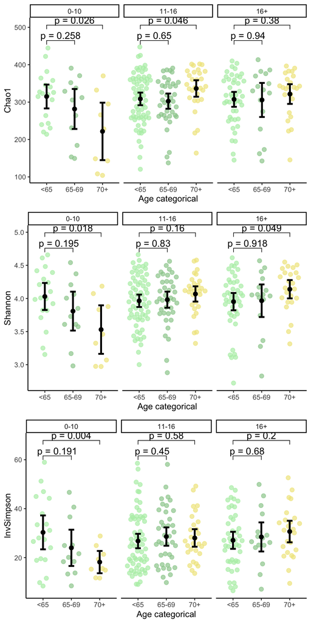

Note. Panels show results stratified by age and education groups with 0-10, 11-16 and 16+ years of education. Reported P values refer to Student’s t-Tests. InvSimpson = Inverse Simpson. Author MK.

## Figure 2. Ordination Plots for Education Groups.

### A ANOVA

|  | Df | Sum Sq | Mean Sq | F value | Pr(>F) |
| --- | --- | --- | --- | --- | --- |
| Groups | 2 | 0.01 | 0 | 1.8 | 0.167 |
| Residuals | 255 | 0.63 | 0 |  |  |

### B ANOVA

|  | Df | Sum Sq | Mean Sq | F value | Pr(>F) |
| --- | --- | --- | --- | --- | --- |
| Groups | 2 | 0.02 | 0.01 | 3.11 | 0.048 |
| Residuals | 126 | 0.32 | 0.00 |  |  |

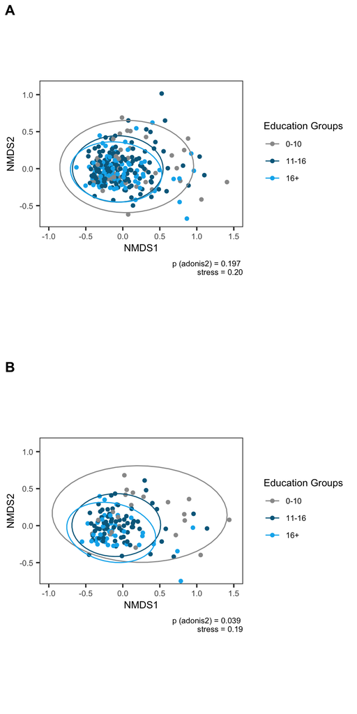

Note. Ordination using Non-metric Multidimensional Scaling based on Bray-Curtis dissimilarity. P value (adonis2) adjusted for gender, age, ATB, BDI-I, first language, PS, and APOE. Ordination using Non-metric Multidimensional Scaling based on Bray-Curtis dissimilarity. A Full sample. B Restricted sample age 65 and older. Authors MK and VTEA.

# Supplement

## Table 1. Coefficients of Regression Models with Chao1.

### Without interaction

Outcome Model

|  | Estimate [95% CI] | P Value | Sig |
| --- | --- | --- | --- |
| (Intercept) | -4.05 [-7.22 to -1.04] | 0.010 | ’*’ |
| Years_of_Education11-16 | -1.21 [-2.07 to -0.35] | 0.006 | ’**’ |
| Years_of_Education16+ | -1.23 [-2.16 to -0.31] | 0.009 | ’**’ |
| zChao1 | -0.21 [-0.54 to 0.11] | 0.198 |  |
| Age | 0.07 [ 0.03 to 0.11] | 0.001 | ’**’ |
| GenderMale | 1.11 [ 0.37 to 1.91] | 0.004 | ’**’ |
| ATB_in_last_6_monthsNO | -0.47 [-1.36 to 0.49] | 0.319 |  |
| BDI_I_mildNo | -0.05 [-0.95 to 0.94] | 0.923 |  |
| First_LanguageFrench/Luxembourgish/German | -0.33 [-1.34 to 0.80] | 0.545 |  |
| Living_With_PartnerYes | -0.11 [-0.83 to 0.63] | 0.761 |  |
| APOE4None | -0.62 [-1.32 to 0.09] | 0.084 |  |

Mediator Model

|  | Estimate [95% CI] | P Value | Sig |
| --- | --- | --- | --- |
| (Intercept) | -1.48 [-2.65 to -0.31] | 0.014 | ’*’ |
| Years_of_Education11-16 | 0.42 [ 0.07 to 0.77] | 0.018 | ’*’ |
| Years_of_Education16+ | 0.38 [ 0.00 to 0.76] | 0.050 |  |
| Age | 0.01 [-0.01 to 0.02] | 0.258 |  |
| GenderMale | 0.06 [-0.21 to 0.32] | 0.671 |  |
| ATB_in_last_6_monthsNO | 0.40 [ 0.02 to 0.77] | 0.039 | ’*’ |
| BDI_I_mildNo | 0.04 [-0.33 to 0.41] | 0.833 |  |
| First_LanguageFrench/Luxembourgish/German | -0.15 [-0.58 to 0.27] | 0.478 |  |
| Living_With_PartnerYes | 0.33 [ 0.07 to 0.60] | 0.015 | ’*’ |
| APOE4None | 0.08 [-0.19 to 0.35] | 0.561 |  |

### With interaction

Outcome Model

|  | Estimate [95% CI] | P Value | Sig |
| --- | --- | --- | --- |
| (Intercept) | -4.09 [-7.27 to -1.06] | 0.010 | ’*’ |
| Years_of_Education11-16 | -1.24 [-2.12 to -0.35] | 0.005 | ’**’ |
| Years_of_Education16+ | -1.26 [-2.22 to -0.30] | 0.010 | ’*’ |
| zChao1 | -0.14 [-0.76 to 0.44] | 0.640 |  |
| Age | 0.07 [ 0.03 to 0.11] | 0.002 | ’**’ |
| GenderMale | 1.10 [ 0.35 to 1.91] | 0.005 | ’**’ |
| ATB_in_last_6_monthsNO | -0.47 [-1.37 to 0.48] | 0.314 |  |
| BDI_I_mildNo | -0.07 [-0.98 to 0.92] | 0.880 |  |
| First_LanguageFrench/Luxembourgish/German | -0.31 [-1.33 to 0.82] | 0.572 |  |
| Living_With_PartnerYes | -0.10 [-0.82 to 0.65] | 0.797 |  |
| APOE4None | -0.63 [-1.33 to 0.08] | 0.080 |  |
| Years_of_Education11-16:zChao1 | -0.02 [-0.80 to 0.79] | 0.967 |  |
| Years_of_Education16+:zChao1 | -0.20 [-1.00 to 0.62] | 0.630 |  |

Mediator Model

|  | Estimate [95% CI] | P Value | Sig |
| --- | --- | --- | --- |
| (Intercept) | -1.48 [-2.65 to -0.31] | 0.014 | ’*’ |
| Years_of_Education11-16 | 0.42 [ 0.07 to 0.77] | 0.018 | ’*’ |
| Years_of_Education16+ | 0.38 [ 0.00 to 0.76] | 0.050 |  |
| Age | 0.01 [-0.01 to 0.02] | 0.258 |  |
| GenderMale | 0.06 [-0.21 to 0.32] | 0.671 |  |
| ATB_in_last_6_monthsNO | 0.40 [ 0.02 to 0.77] | 0.039 | ’*’ |
| BDI_I_mildNo | 0.04 [-0.33 to 0.41] | 0.833 |  |
| First_LanguageFrench/Luxembourgish/German | -0.15 [-0.58 to 0.27] | 0.478 |  |
| Living_With_PartnerYes | 0.33 [ 0.07 to 0.60] | 0.015 | ’*’ |
| APOE4None | 0.08 [-0.19 to 0.35] | 0.561 |  |

Note. Regression coefficients for mediator and outcome models, used for mediation analysis with alpha diversity measures. All analyses were adjusted for age, sex/gender, ATB, BDI-I, first language, PS and APOE. * P Value < .05, ** P Value < .01, *** P Value < .001.

## Table 2. Coefficients of Regression Models with Shannon.

### Without interaction

Outcome Model

|  | Estimate [95% CI] | P Value | Sig |
| --- | --- | --- | --- |
| (Intercept) | -3.89 [-7.01 to -0.90] | 0.012 | ’*’ |
| Years_of_Education11-16 | -1.26 [-2.11 to -0.41] | 0.003 | ’**’ |
| Years_of_Education16+ | -1.25 [-2.18 to -0.34] | 0.007 | ’**’ |
| zShannon | -0.13 [-0.46 to 0.19] | 0.423 |  |
| Age | 0.06 [ 0.03 to 0.11] | 0.002 | ’**’ |
| GenderMale | 1.10 [ 0.37 to 1.90] | 0.005 | ’**’ |
| ATB_in_last_6_monthsNO | -0.49 [-1.38 to 0.46] | 0.289 |  |
| BDI_I_mildNo | -0.06 [-0.96 to 0.91] | 0.893 |  |
| First_LanguageFrench/Luxembourgish/German | -0.31 [-1.33 to 0.81] | 0.562 |  |
| Living_With_PartnerYes | -0.16 [-0.87 to 0.57] | 0.666 |  |
| APOE4None | -0.63 [-1.33 to 0.07] | 0.077 |  |

Mediator Model

|  | Estimate [95% CI] | P Value | Sig |
| --- | --- | --- | --- |
| (Intercept) | -1.62 [-2.79 to -0.44] | 0.007 | ’**’ |
| Years_of_Education11-16 | 0.36 [ 0.01 to 0.71] | 0.042 | ’*’ |
| Years_of_Education16+ | 0.37 [-0.01 to 0.75] | 0.055 |  |
| Age | 0.01 [ 0.00 to 0.03] | 0.102 |  |
| GenderMale | 0.09 [-0.17 to 0.35] | 0.494 |  |
| ATB_in_last_6_monthsNO | 0.43 [ 0.05 to 0.80] | 0.026 | ’*’ |
| BDI_I_mildNo | 0.05 [-0.32 to 0.42] | 0.778 |  |
| First_LanguageFrench/Luxembourgish/German | -0.20 [-0.62 to 0.23] | 0.364 |  |
| Living_With_PartnerYes | 0.26 [-0.01 to 0.53] | 0.057 |  |
| APOE4None | 0.01 [-0.26 to 0.28] | 0.938 |  |

### With interaction

Outcome Model

|  | Estimate [95% CI] | P Value | Sig |
| --- | --- | --- | --- |
| (Intercept) | -4.10 [-7.27 to -1.08] | 0.009 | ’**’ |
| Years_of_Education11-16 | -1.31 [-2.18 to -0.45] | 0.003 | ’**’ |
| Years_of_Education16+ | -1.28 [-2.22 to -0.36] | 0.007 | ’**’ |
| zShannon | -0.01 [-0.61 to 0.59] | 0.985 |  |
| Age | 0.07 [ 0.03 to 0.11] | 0.001 | ’**’ |
| GenderMale | 1.08 [ 0.34 to 1.87] | 0.006 | ’**’ |
| ATB_in_last_6_monthsNO | -0.51 [-1.40 to 0.45] | 0.279 |  |
| BDI_I_mildNo | -0.11 [-1.02 to 0.88] | 0.825 |  |
| First_LanguageFrench/Luxembourgish/German | -0.29 [-1.32 to 0.84] | 0.591 |  |
| Living_With_PartnerYes | -0.14 [-0.85 to 0.59] | 0.698 |  |
| APOE4None | -0.64 [-1.34 to 0.06] | 0.072 |  |
| Years_of_Education11-16:zShannon | 0.04 [-0.77 to 0.87] | 0.924 |  |
| Years_of_Education16+:zShannon | -0.38 [-1.19 to 0.43] | 0.354 |  |

Mediator Model

|  | Estimate [95% CI] | P Value | Sig |
| --- | --- | --- | --- |
| (Intercept) | -1.62 [-2.79 to -0.44] | 0.007 | ’**’ |
| Years_of_Education11-16 | 0.36 [ 0.01 to 0.71] | 0.042 | ’*’ |
| Years_of_Education16+ | 0.37 [-0.01 to 0.75] | 0.055 |  |
| Age | 0.01 [ 0.00 to 0.03] | 0.102 |  |
| GenderMale | 0.09 [-0.17 to 0.35] | 0.494 |  |
| ATB_in_last_6_monthsNO | 0.43 [ 0.05 to 0.80] | 0.026 | ’*’ |
| BDI_I_mildNo | 0.05 [-0.32 to 0.42] | 0.778 |  |
| First_LanguageFrench/Luxembourgish/German | -0.20 [-0.62 to 0.23] | 0.364 |  |
| Living_With_PartnerYes | 0.26 [-0.01 to 0.53] | 0.057 |  |
| APOE4None | 0.01 [-0.26 to 0.28] | 0.938 |  |

Note. Regression coefficients for mediator and outcome models, used for mediation analysis with alpha diversity measures. All analyses were adjusted for age, sex/gender, ATB, BDI-I, first language, PS and APOE. * P Value < .05, ** P Value < .01, *** P Value < .001.

## Table 3. Coefficients of Regression Models with Inverse Simpson.

### Without interaction

Outcome Model

|  | Estimate [95% CI] | P Value | Sig |
| --- | --- | --- | --- |
| (Intercept) | -3.72 [-6.78 to -0.79] | 0.014 | ’*’ |
| Years_of_Education11-16 | -1.29 [-2.14 to -0.46] | 0.002 | ’**’ |
| Years_of_Education16+ | -1.28 [-2.21 to -0.38] | 0.006 | ’**’ |
| zInvSimpson | -0.08 [-0.42 to 0.25] | 0.625 |  |
| Age | 0.06 [ 0.02 to 0.10] | 0.002 | ’**’ |
| GenderMale | 1.09 [ 0.36 to 1.89] | 0.005 | ’**’ |
| ATB_in_last_6_monthsNO | -0.53 [-1.41 to 0.42] | 0.254 |  |
| BDI_I_mildNo | -0.08 [-0.97 to 0.88] | 0.862 |  |
| First_LanguageFrench/Luxembourgish/German | -0.31 [-1.32 to 0.82] | 0.567 |  |
| Living_With_PartnerYes | -0.18 [-0.88 to 0.55] | 0.629 |  |
| APOE4None | -0.63 [-1.33 to 0.08] | 0.077 |  |

Mediator Model

|  | Estimate [95% CI] | P Value | Sig |
| --- | --- | --- | --- |
| (Intercept) | -0.88 [-2.08 to 0.31] | 0.147 |  |
| Years_of_Education11-16 | 0.17 [-0.18 to 0.52] | 0.342 |  |
| Years_of_Education16+ | 0.22 [-0.16 to 0.61] | 0.260 |  |
| Age | 0.01 [-0.01 to 0.02] | 0.411 |  |
| GenderMale | 0.05 [-0.22 to 0.31] | 0.741 |  |
| ATB_in_last_6_monthsNO | 0.24 [-0.14 to 0.62] | 0.218 |  |
| BDI_I_mildNo | 0.02 [-0.35 to 0.40] | 0.903 |  |
| First_LanguageFrench/Luxembourgish/German | -0.20 [-0.63 to 0.23] | 0.357 |  |
| Living_With_PartnerYes | 0.31 [ 0.04 to 0.58] | 0.026 | ’*’ |
| APOE4None | 0.02 [-0.25 to 0.30] | 0.882 |  |

### With interaction

Outcome Model

|  | Estimate [95% CI] | P Value | Sig |
| --- | --- | --- | --- |
| (Intercept) | -4.10 [-7.24 to -1.11] | 0.008 | ’**’ |
| Years_of_Education11-16 | -1.33 [-2.18 to -0.48] | 0.002 | ’**’ |
| Years_of_Education16+ | -1.30 [-2.23 to -0.39] | 0.005 | ’**’ |
| zInvSimpson | -0.01 [-0.68 to 0.63] | 0.975 |  |
| Age | 0.07 [ 0.03 to 0.11] | <0.001 | ’***’ |
| GenderMale | 1.08 [ 0.34 to 1.87] | 0.006 | ’**’ |
| ATB_in_last_6_monthsNO | -0.57 [-1.47 to 0.39] | 0.226 |  |
| BDI_I_mildNo | -0.06 [-0.97 to 0.92] | 0.899 |  |
| First_LanguageFrench/Luxembourgish/German | -0.32 [-1.36 to 0.82] | 0.560 |  |
| Living_With_PartnerYes | -0.15 [-0.86 to 0.58] | 0.683 |  |
| APOE4None | -0.66 [-1.36 to 0.05] | 0.067 |  |
| Years_of_Education11-16:zInvSimpson | 0.19 [-0.62 to 1.02] | 0.649 |  |
| Years_of_Education16+:zInvSimpson | -0.50 [-1.41 to 0.41] | 0.282 |  |

Mediator Model

|  | Estimate [95% CI] | P Value | Sig |
| --- | --- | --- | --- |
| (Intercept) | -0.88 [-2.08 to 0.31] | 0.147 |  |
| Years_of_Education11-16 | 0.17 [-0.18 to 0.52] | 0.342 |  |
| Years_of_Education16+ | 0.22 [-0.16 to 0.61] | 0.260 |  |
| Age | 0.01 [-0.01 to 0.02] | 0.411 |  |
| GenderMale | 0.05 [-0.22 to 0.31] | 0.741 |  |
| ATB_in_last_6_monthsNO | 0.24 [-0.14 to 0.62] | 0.218 |  |
| BDI_I_mildNo | 0.02 [-0.35 to 0.40] | 0.903 |  |
| First_LanguageFrench/Luxembourgish/German | -0.20 [-0.63 to 0.23] | 0.357 |  |
| Living_With_PartnerYes | 0.31 [ 0.04 to 0.58] | 0.026 | ’*’ |
| APOE4None | 0.02 [-0.25 to 0.30] | 0.882 |  |

Note. Regression coefficients for mediator and outcome models, used for mediation analysis with alpha diversity measures. All analyses were adjusted for age, sex/gender, ATB, BDI-I, first language, PS and APOE. * P Value < .05, ** P Value < .01, *** P Value < .001.

## Table 4. Mediation Analysis with Shannon Index as Mediator.

### 0-10 vs. 11-16

11-16 vs. 0-10 YEDU - Shannon - no interaction

| Effect | Estimate [95% CI] | P Value | Sig |
| --- | --- | --- | --- |
| Rcde | 0.32 [ 0.15 to 0.69] | 0.007 | ’**’ |
| Rpnde | 0.32 [ 0.15 to 0.70] | 0.007 | ’**’ |
| Rtnde | 0.32 [ 0.15 to 0.70] | 0.007 | ’**’ |
| Rpnie | 0.96 [ 0.83 to 1.09] | 0.526 |  |
| Rtnie | 0.96 [ 0.82 to 1.10] | 0.526 |  |
| Rte | 0.31 [ 0.15 to 0.67] | 0.004 | ’**’ |
| pm | 0.02 [-0.06 to 0.17] | 0.527 |  |

### 0-10 vs. 16+

16+ vs. 0-10 YEDU - Shannon - no interaction

| Effect | Estimate [95% CI] | P Value | Sig |
| --- | --- | --- | --- |
| Rcde | 0.33 [ 0.14 to 0.75] | 0.014 | ’*’ |
| Rpnde | 0.33 [ 0.14 to 0.75] | 0.014 | ’*’ |
| Rtnde | 0.33 [ 0.14 to 0.75] | 0.014 | ’*’ |
| Rpnie | 0.96 [ 0.81 to 1.10] | 0.531 |  |
| Rtnie | 0.96 [ 0.81 to 1.10] | 0.531 |  |
| Rte | 0.31 [ 0.14 to 0.71] | 0.008 | ’**’ |
| pm | 0.02 [-0.05 to 0.20] | 0.535 |  |

### 0-10 vs. 11-16 with interaction

11-16 vs. 0-10 YEDU - Shannon - with interaction

| Effect | Estimate [95% CI] | P Value | Sig |
| --- | --- | --- | --- |
| Rcde | 0.31 [ 0.14 to 0.69] | 0.007 | ’**’ |
| Rpnde | 0.31 [ 0.14 to 0.69] | 0.007 | ’**’ |
| Rtnde | 0.31 [ 0.14 to 0.70] | 0.008 | ’**’ |
| Rpnie | 1.00 [ 0.80 to 1.25] | 0.986 |  |
| Rtnie | 1.01 [ 0.79 to 1.40] | 0.897 |  |
| Rte | 0.31 [ 0.15 to 0.67] | 0.005 | ’**’ |
| ERcde | -0.56 [-0.77 to -0.22] | 0.007 | ’**’ |
| ERintref | -0.13 [-0.26 to 0.03] | 0.093 |  |
| ERintmed | 0.01 [-0.26 to 0.23] | 0.961 |  |
| ERpnie | 0.00 [-0.20 to 0.25] | 0.986 |  |
| ERcde(prop) | 0.81 [ 0.58 to 1.06] | 0.003 | ’**’ |
| ERintref(prop) | 0.19 [-0.07 to 0.46] | 0.094 |  |
| ERintmed(prop) | -0.01 [-0.43 to 0.44] | 0.963 |  |
| ERpnie(prop) | 0.00 [-0.42 to 0.35] | 0.988 |  |
| pm | -0.01 [-0.21 to 0.17] | 0.898 |  |
| int | 0.19 [-0.03 to 0.45] | 0.070 |  |
| pe | 0.19 [-0.06 to 0.42] | 0.107 |  |

### 0-10 vs. 16+ with interaction

16+ vs. 0-10 YEDU - Shannon - with interaction

| Effect | Estimate [95% CI] | P Value | Sig |
| --- | --- | --- | --- |
| Rcde | 0.32 [ 0.13 to 0.74] | 0.012 | ’*’ |
| Rpnde | 0.36 [ 0.15 to 0.86] | 0.022 | ’*’ |
| Rtnde | 0.32 [ 0.14 to 0.74] | 0.011 | ’*’ |
| Rpnie | 1.00 [ 0.79 to 1.26] | 0.985 |  |
| Rtnie | 0.88 [ 0.65 to 1.09] | 0.260 |  |
| Rte | 0.32 [ 0.15 to 0.72] | 0.009 | ’**’ |
| ERcde | -0.55 [-0.78 to -0.18] | 0.012 | ’*’ |
| ERintref | -0.09 [-0.21 to 0.17] | 0.344 |  |
| ERintmed | -0.04 [-0.37 to 0.17] | 0.677 |  |
| ERpnie | 0.00 [-0.21 to 0.26] | 0.985 |  |
| ERcde(prop) | 0.80 [ 0.56 to 1.05] | 0.005 | ’**’ |
| ERintref(prop) | 0.13 [-0.34 to 0.34] | 0.336 |  |
| ERintmed(prop) | 0.06 [-0.28 to 0.71] | 0.682 |  |
| ERpnie(prop) | 0.00 [-0.43 to 0.37] | 0.988 |  |
| pm | 0.06 [-0.05 to 0.49] | 0.266 |  |
| int | 0.19 [ 0.00 to 0.49] | 0.053 |  |
| pe | 0.20 [-0.05 to 0.44] | 0.089 |  |

## Table 5. Mediation Analysis with Inverse Simpson as Mediator.

### 0-10 vs. 11-16

11-16 vs. 0-10 YEDU - InvSimpson - no interaction

| Effect | Estimate [95% CI] | P Value | Sig |
| --- | --- | --- | --- |
| Rcde | 0.31 [ 0.15 to 0.67] | 0.005 | ’**’ |
| Rpnde | 0.31 [ 0.15 to 0.67] | 0.005 | ’**’ |
| Rtnde | 0.31 [ 0.15 to 0.67] | 0.005 | ’**’ |
| Rpnie | 0.99 [ 0.89 to 1.08] | 0.832 |  |
| Rtnie | 0.99 [ 0.88 to 1.08] | 0.832 |  |
| Rte | 0.31 [ 0.15 to 0.67] | 0.005 | ’**’ |
| pm | 0.01 [-0.05 to 0.09] | 0.833 |  |

### 0-10 vs. 16+

16+ vs. 0-10 YEDU - InvSimpson - no interaction

| Effect | Estimate [95% CI] | P Value | Sig |
| --- | --- | --- | --- |
| Rcde | 0.32 [ 0.14 to 0.73] | 0.009 | ’**’ |
| Rpnde | 0.32 [ 0.14 to 0.73] | 0.009 | ’**’ |
| Rtnde | 0.32 [ 0.14 to 0.73] | 0.009 | ’**’ |
| Rpnie | 0.98 [ 0.87 to 1.09] | 0.762 |  |
| Rtnie | 0.98 [ 0.86 to 1.10] | 0.762 |  |
| Rte | 0.31 [ 0.14 to 0.71] | 0.008 | ’**’ |
| pm | 0.01 [-0.05 to 0.12] | 0.764 |  |

### 0-10 vs. 11-16 with interaction

11-16 vs. 0-10 YEDU - InvSimpson - with interaction

| Effect | Estimate [95% CI] | P Value | Sig |
| --- | --- | --- | --- |
| Rcde | 0.31 [ 0.14 to 0.68] | 0.005 | ’**’ |
| Rpnde | 0.30 [ 0.15 to 0.66] | 0.004 | ’**’ |
| Rtnde | 0.31 [ 0.15 to 0.69] | 0.006 | ’**’ |
| Rpnie | 1.00 [ 0.85 to 1.20] | 0.964 |  |
| Rtnie | 1.03 [ 0.89 to 1.24] | 0.705 |  |
| Rte | 0.31 [ 0.15 to 0.67] | 0.005 | ’**’ |
| ERcde | -0.56 [-0.77 to -0.24] | 0.005 | ’**’ |
| ERintref | -0.13 [-0.25 to 0.00] | 0.055 |  |
| ERintmed | 0.01 [-0.19 to 0.18] | 0.966 |  |
| ERpnie | 0.00 [-0.15 to 0.20] | 0.964 |  |
| ERcde(prop) | 0.82 [ 0.61 to 1.02] | 0.004 | ’**’ |
| ERintref(prop) | 0.20 [ 0.00 to 0.44] | 0.054 |  |
| ERintmed(prop) | -0.01 [-0.33 to 0.33] | 0.965 |  |
| ERpnie(prop) | 0.00 [-0.34 to 0.27] | 0.965 |  |
| pm | -0.01 [-0.14 to 0.07] | 0.705 |  |
| int | 0.18 [ 0.02 to 0.40] | 0.039 | ’*’ |
| pe | 0.18 [-0.02 to 0.39] | 0.066 |  |

### 0-10 vs. 16+ with interaction

16+ vs. 0-10 YEDU - InvSimpson - with interaction

| Effect | Estimate [95% CI] | P Value | Sig |
| --- | --- | --- | --- |
| Rcde | 0.32 [ 0.13 to 0.73] | 0.010 | ’*’ |
| Rpnde | 0.36 [ 0.16 to 0.83] | 0.020 | ’*’ |
| Rtnde | 0.32 [ 0.14 to 0.75] | 0.010 | ’*’ |
| Rpnie | 1.00 [ 0.83 to 1.25] | 0.991 |  |
| Rtnie | 0.91 [ 0.67 to 1.10] | 0.370 |  |
| Rte | 0.32 [ 0.15 to 0.73] | 0.009 | ’**’ |
| ERcde | -0.55 [-0.78 to -0.20] | 0.010 | ’*’ |
| ERintref | -0.09 [-0.19 to 0.17] | 0.326 |  |
| ERintmed | -0.03 [-0.36 to 0.12] | 0.701 |  |
| ERpnie | 0.00 [-0.17 to 0.25] | 0.991 |  |
| ERcde(prop) | 0.81 [ 0.58 to 1.10] | 0.003 | ’**’ |
| ERintref(prop) | 0.14 [-0.35 to 0.33] | 0.318 |  |
| ERintmed(prop) | 0.05 [-0.21 to 0.67] | 0.705 |  |
| ERpnie(prop) | 0.00 [-0.40 to 0.31] | 0.990 |  |
| pm | 0.05 [-0.07 to 0.41] | 0.375 |  |
| int | 0.18 [-0.04 to 0.48] | 0.084 |  |
| pe | 0.19 [-0.10 to 0.42] | 0.114 |  |

## Table 6. Taxonomic Classification of Identified Taxa.

| Taxon | Domain | Phylum | Class | Order | Family | Genus |
| --- | --- | --- | --- | --- | --- | --- |
| Bacilli | Bacteria | Firmicutes | Bacilli |  |  |  |
| Lactobacillales | Bacteria | Firmicutes | Bacilli | Lactobacillales |  |  |
| Streptococcaceae | Bacteria | Firmicutes | Bacilli | Lactobacillales | Streptococcaceae |  |
| Actinobacteria | Bacteria | Actinobacteriota | Actinobacteria |  |  |  |
| Streptococcus | Bacteria | Firmicutes | Bacilli | Lactobacillales | Streptococcaceae | Streptococcus |
| Lachnospiraceae_UCG_001 | Bacteria | Firmicutes | Clostridia | Lachnospirales | Lachnospiraceae | Lachnospiraceae_UCG_001 |
| OTU_000053 | Bacteria | Firmicutes | Clostridia | Oscillospirales | Oscillospiraceae | NK4A214_group |
| OTU_000508 | Bacteria | Firmicutes | Clostridia | Lachnospirales | Lachnospiraceae | Lachnospiraceae_UCG_001 |

## Table 7. First Languages Spoken.

|  | NC | MCI |
| --- | --- | --- |
| Danish | 3 | 0 |
| Dutch | 2 | 1 |
| English | 7 | 0 |
| French | 27 | 5 |
| German | 20 | 3 |
| Hungarian | 1 | 0 |
| Italian | 2 | 2 |
| Luxembourgish | 135 | 44 |
| Portuguese | 1 | 3 |
| Slovene | 1 | 0 |
| Spanish | 1 | 0 |

## Figure 1. Alpha Diversity Across Education Groups.

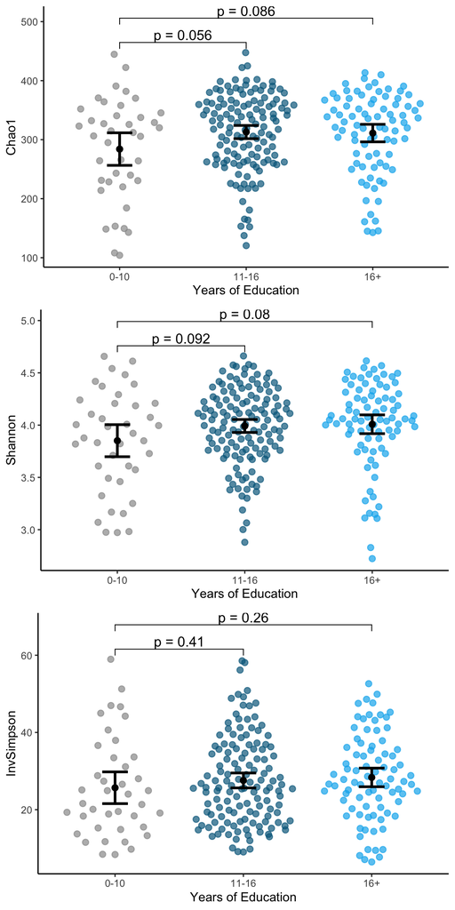

Note. Panels show results stratified by education groups with 0-10, 11-16 and 16+ years of education. Reported P values refer to Student’s t-Tests. InvSimpson = Inverse Simpson. Author MK.

## Figure 2. Ordination Plots for MCI and Age Groups.

Ordination using Non-metric Multidimensional Scaling based on Bray-Curtis dissimilarity. P value (adonis2) adjusted for MCI, education, gender, age, ATB, BDI-I, first language, PS, APOE. Authors MK and VTEA.

### A MCI

|  | Df | Sum Sq | Mean Sq | F value | Pr(>F) |
| --- | --- | --- | --- | --- | --- |
| Groups | 1 | 0.01 | 0.01 | 2.25 | 0.135 |
| Residuals | 256 | 0.63 | 0.00 |  |  |

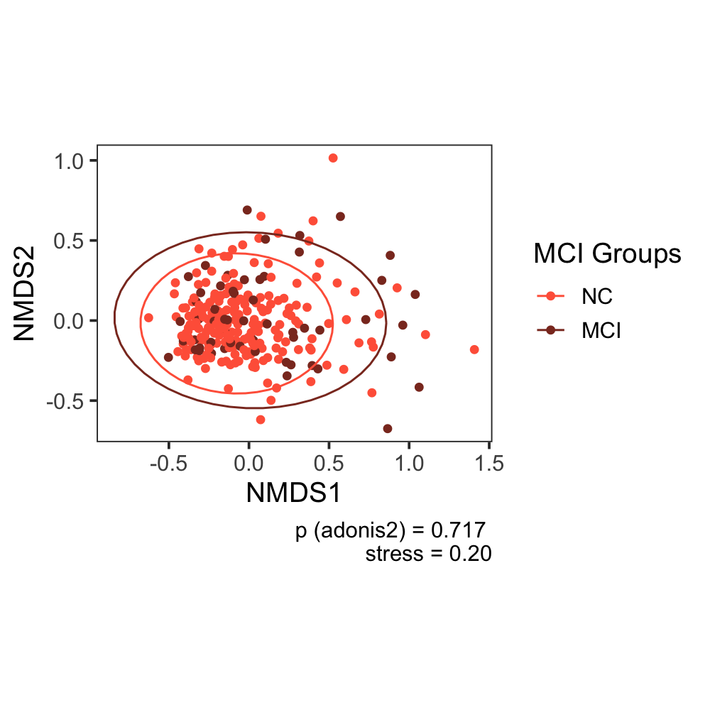

### B Age

|  | Df | Sum Sq | Mean Sq | F value | Pr(>F) |
| --- | --- | --- | --- | --- | --- |
| Groups | 2 | 0.00 | 0 | 0.01 | 0.987 |
| Residuals | 255 | 0.65 | 0 |  |  |

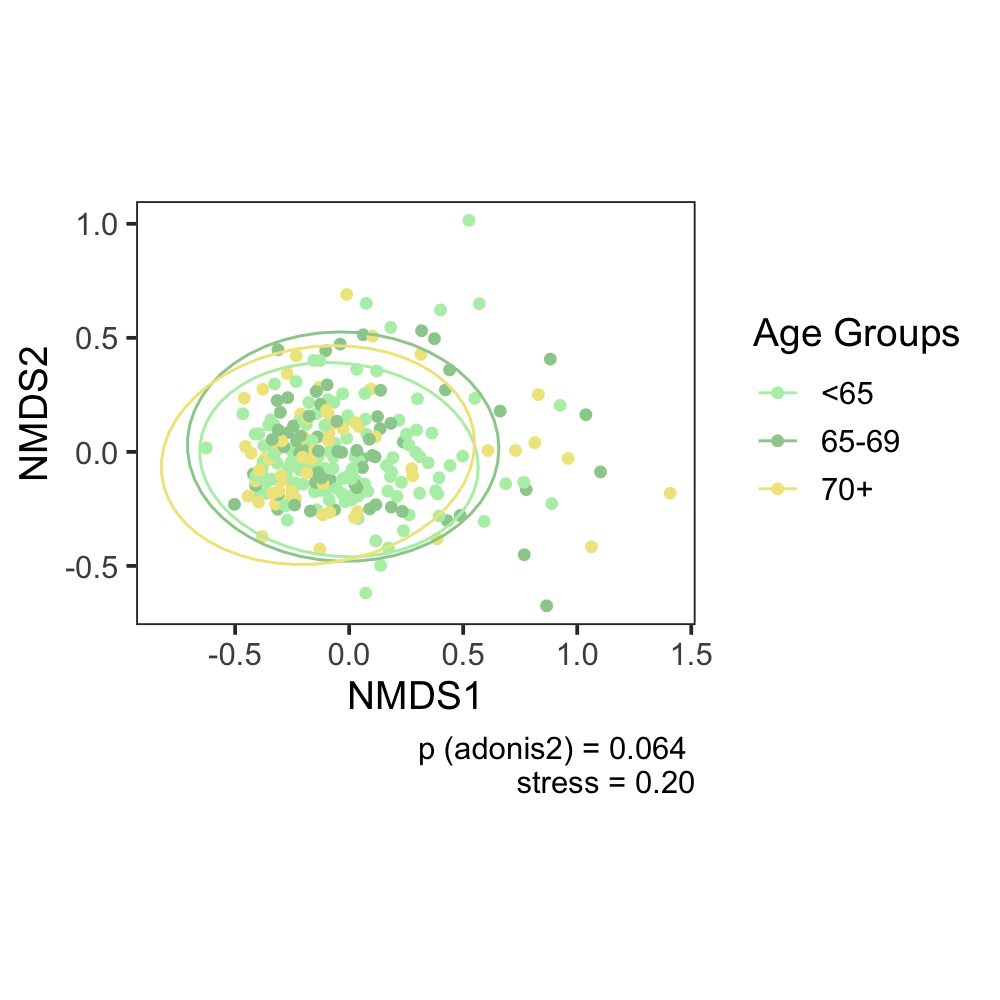

## Figure 3. Relative Abundance Across Groups of Education.

### Bacilli

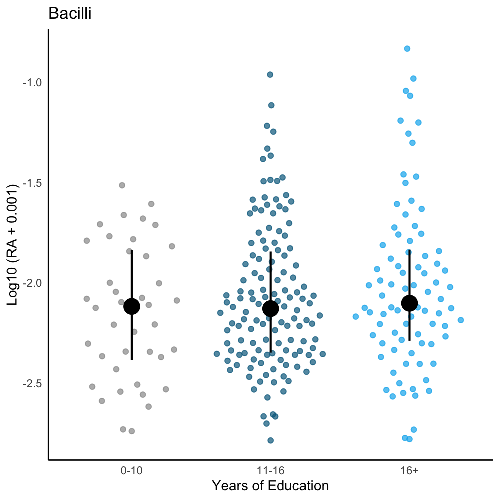

### Lactobacillales

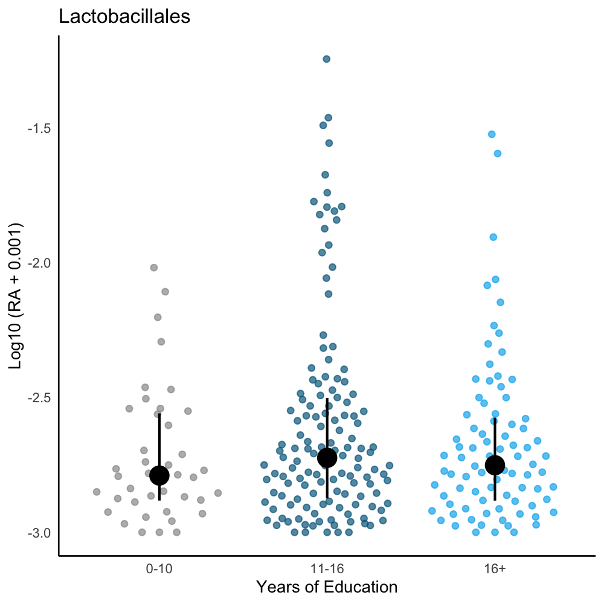

### Streptococcaceae

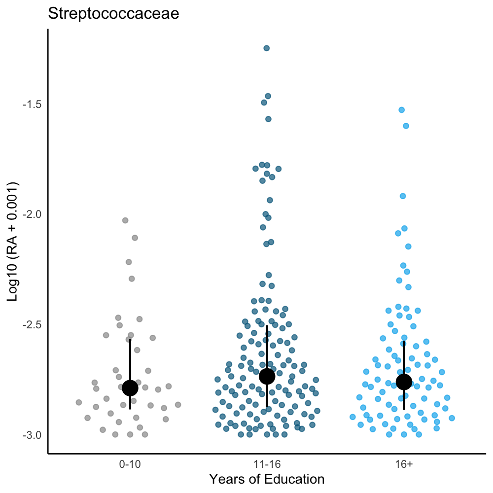

### Actinobacteria

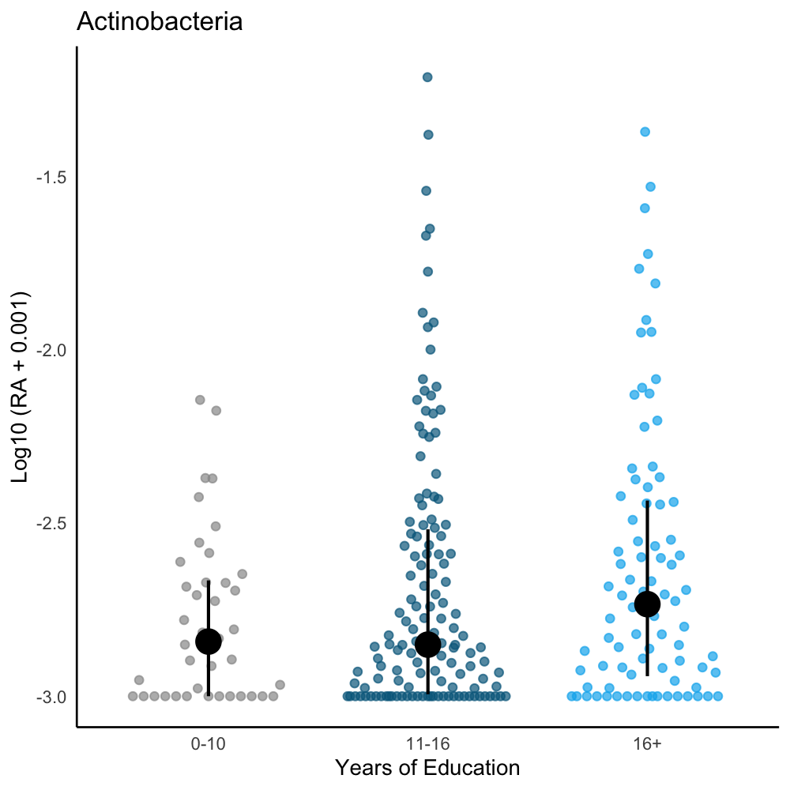

### Streptococcus

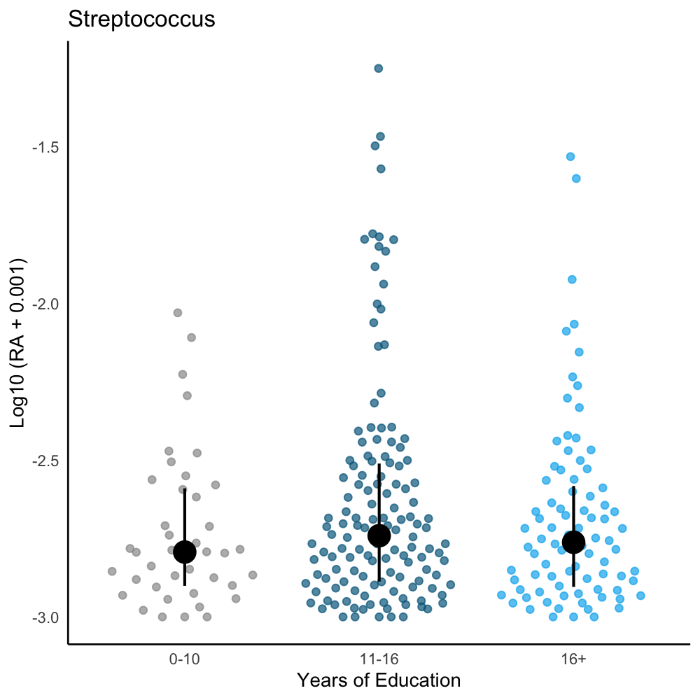

### Lachnospiraceae_UCG_001

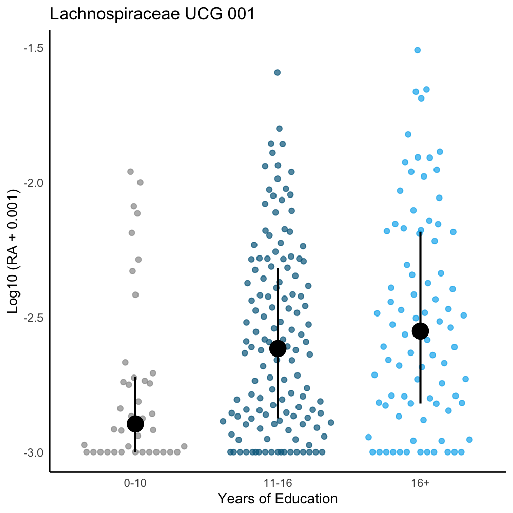

### OTU_000053

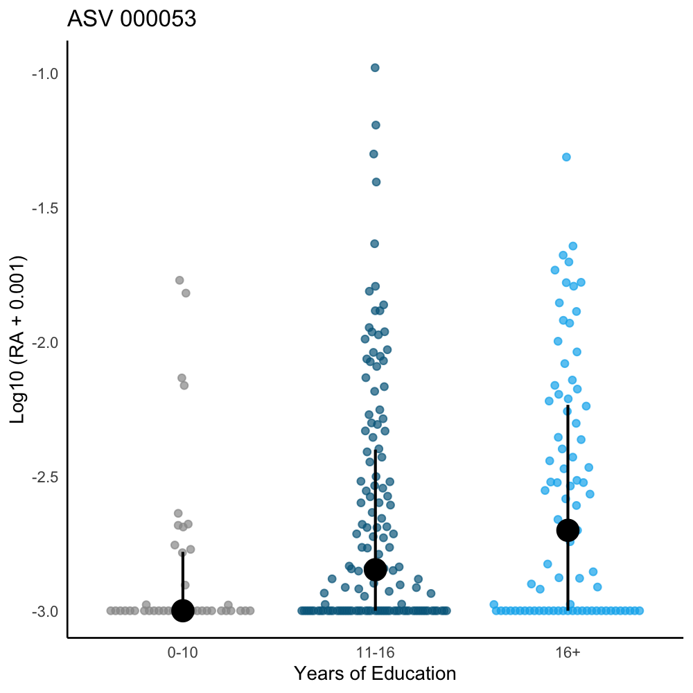

### OTU_000508

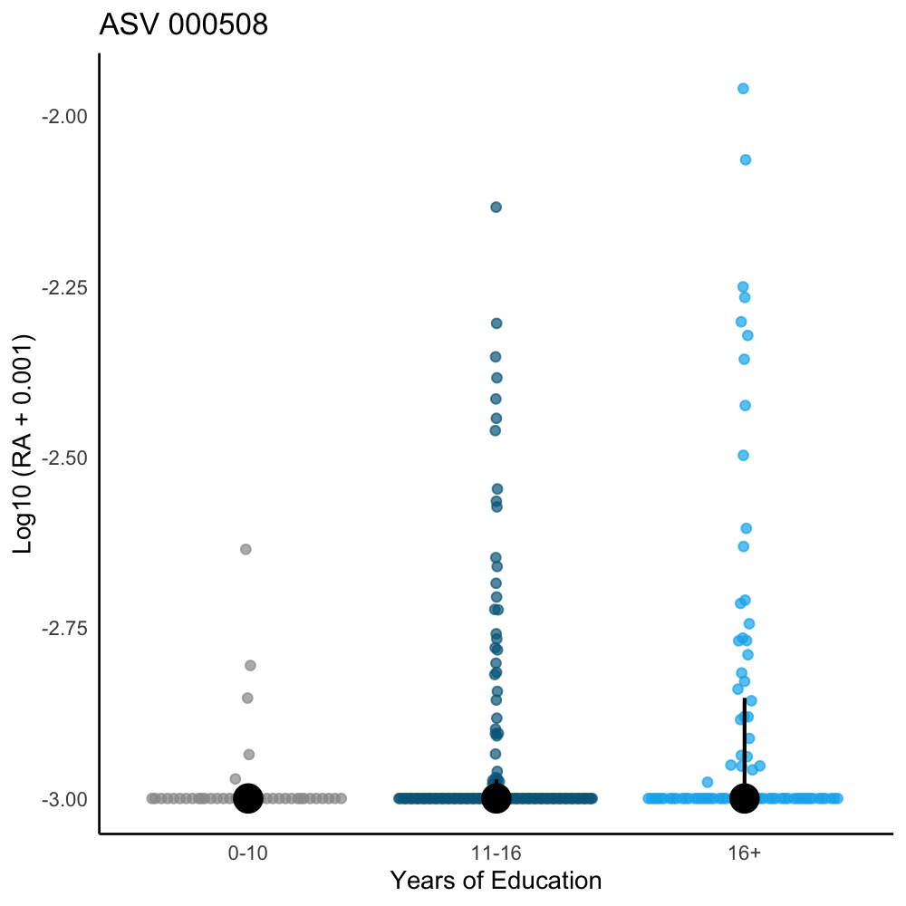